# Modern Data Mining, HW 2

Daniel Park

Elliot Banks

Wilson Zhang

Due: 11:59 PM, Sunday, 02/22

# 1 Case Study 3: Fuel Efficiency in Automobiles

What determines how fuel efficient a car is? Are Japanese cars more fuel efficient? To answer thes questions we will build various linear models using the `Auto` dataset from the book `ISLR`. The original dataset contains information for about 400 different cars built in various years. To get the data, first install the package ISLR which has been done in the first R-chunk. The `Auto` dataset should be loaded automatically. Original data source is here: https://archive.ics.uci.edu/ml/datasets/auto+mpg

Get familiar with this dataset first. Tip: you can use the command `?ISLR::Auto` to view a description of the dataset. Our response variable will me `MPG`: miles per gallon.

## 1.1 EDA

```
##       mpg         cylinders     displacement   horsepower        weight
##  Min.   : 9.0   Min.   :3.00   Min.   : 68   Min.   : 46.0   Min.   :1613
##  1st Qu.:17.0   1st Qu.:4.00   1st Qu.:105   1st Qu.: 75.0   1st Qu.:2225
##  Median :22.8   Median :4.00   Median :151   Median : 93.5   Median :2804
##  Mean   :23.4   Mean   :5.47   Mean   :194   Mean   :104.5   Mean   :2978
##  3rd Qu.:29.0   3rd Qu.:8.00   3rd Qu.:276   3rd Qu.:126.0   3rd Qu.:3615
##  Max.   :46.6   Max.   :8.00   Max.   :455   Max.   :230.0   Max.   :5140
##
##   acceleration       year        origin                     name
##  Min.   : 8.0   Min.   :70   Min.   :1.00   amc matador       :  5
##  1st Qu.:13.8   1st Qu.:73   1st Qu.:1.00   ford pinto        :  5
##  Median :15.5   Median :76   Median :1.00   toyota corolla    :  5
##  Mean   :15.5   Mean   :76   Mean   :1.58   amc gremlin       :  4
##  3rd Qu.:17.0   3rd Qu.:79   3rd Qu.:2.00   amc hornet        :  4
##  Max.   :24.8   Max.   :82   Max.   :3.00   chevrolet chevette:  4
##                                             (Other)           :365
```

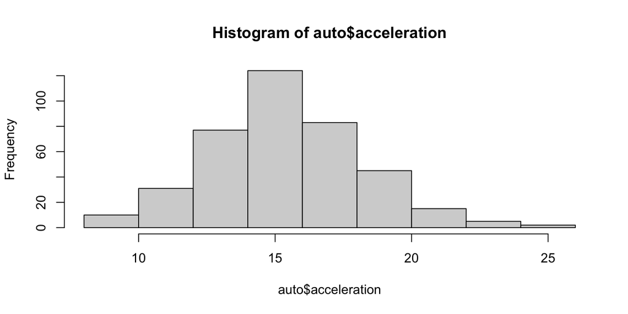

[output not shown]

[output cut: 771 more lines]

1. Explore the data, list the variables with clear definitions. Set each variable with its appropriate class. For example `origin` should be set as a factor.

Explaining the Variables:

All variables except `origin` and `name` are numeric. `origin` is a categorical factor that represents the country of manufacture.

2. How many cars are included in this data set?

```
## [1] 392
```

392 cars are included in this data set.

3. EDA, focus on pairwise plots and summary statistics. Briefly summarize your findings and any peculiarities in the data.

```
##   mean_mpg sd_mpg min_mpg max_mpg
## 1     23.4   7.81       9    46.6
```

The average mpg was 23.4, with the least fuel economic car achieving only 9 mpg, while the more fuel economic car achieved 46.6 mpg. There is moderate variation in the mpg, with a standard deviation of 7.81 mpg.

```
## # A tibble: 3 × 3
##   origin mean_mpg sd_mpg
##   <fct>     <dbl>  <dbl>
## 1 USA        20.0   6.44
## 2 Europe     27.6   6.58
## 3 Japan      30.5   6.09
```

Grouping the vehicles by country, the mean and standard deviation of fuel economy reveals that Japanese cars on average have the greatest mpg at 30.5, followed by European then American vehicles.

The fuel economy in Japanese cars was also the most consistent, with a standard deviation of 6.09 mpg, compared to 6.58 and 6.44 mpg for European and American cars respectively.

Relationship between Displacement and MPG

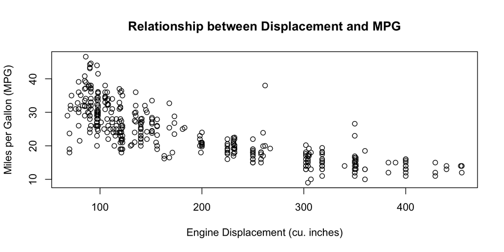

The scatterplot above shows that as the engine’s displacement increases, the MPG decreases.

Relationship between Weight and MPG

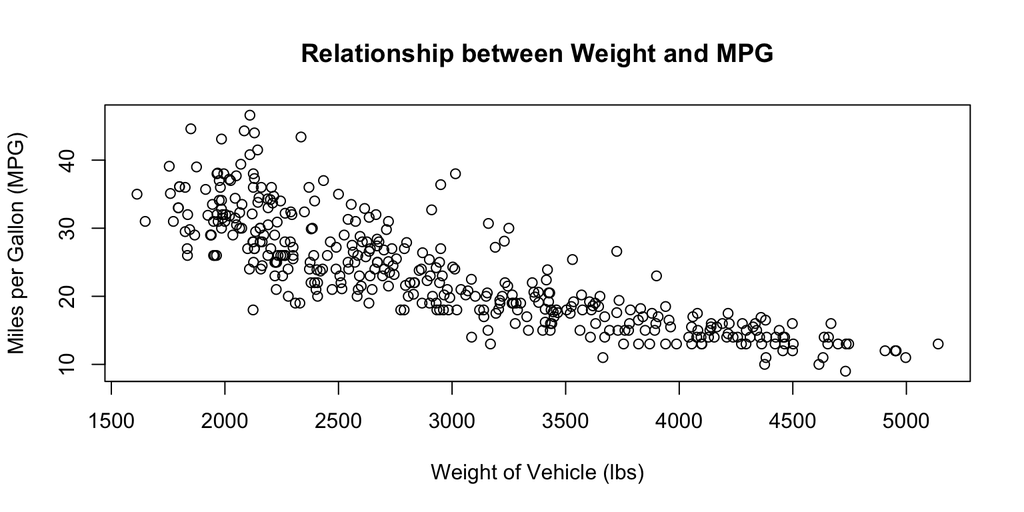

Relationship between Acceleration and MPG

[figure not shown]

## 1.2 What effect does `time` have on `MPG`?

1. Start with a simple regression of `mpg` vs. `year` and report R’s `summary` output. Is `year` a significant variable at the .05 level? State what effect `year` has on `mpg`, if any, according to this model.

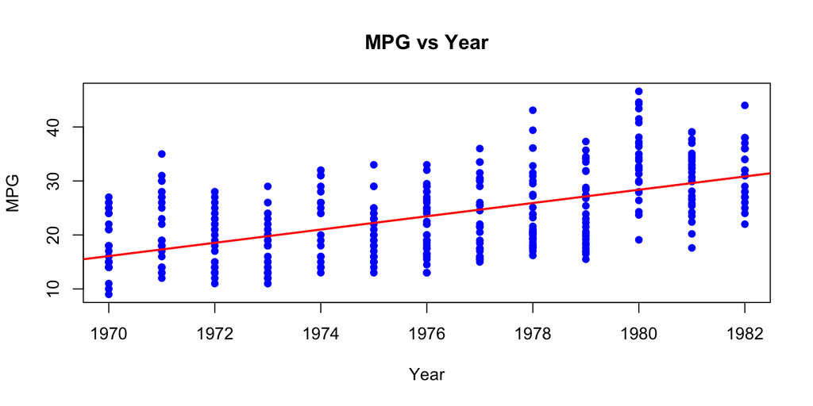

```
##                2.5 %  97.5 %
## (Intercept) -2746.46 -2067.7
## year            1.06     1.4
```

```
##
## Call:
## lm(formula = mpg ~ year, data = auto)
##
## Residuals:
##     Min      1Q  Median      3Q     Max
## -12.021  -5.441  -0.441   4.974  18.209
##
## Coefficients:
##              Estimate Std. Error t value Pr(>|t|)
## (Intercept) -2.41e+03   1.73e+02   -13.9   <2e-16 ***
## year         1.23e+00   8.74e-02    14.1   <2e-16 ***
## ---
## Signif. codes:  0 '***' 0.001 '**' 0.01 '*' 0.05 '.' 0.1 ' ' 1
##
## Residual standard error: 6.36 on 390 degrees of freedom
## Multiple R-squared:  0.337,  Adjusted R-squared:  0.335
## F-statistic:  198 on 1 and 390 DF,  p-value: <2e-16
```

The p-value for this linear model is <2e-16. Hence, we can conclude that year is a significant variable at the .05 level. The regression line suggests that on average, as the year increases, the mpg increases by 1.23.

2. Add `horsepower` on top of the variable `year` to your linear model. Is `year` still a significant variable at the .05 level? Give a precise interpretation of the `year`’s effect found here.

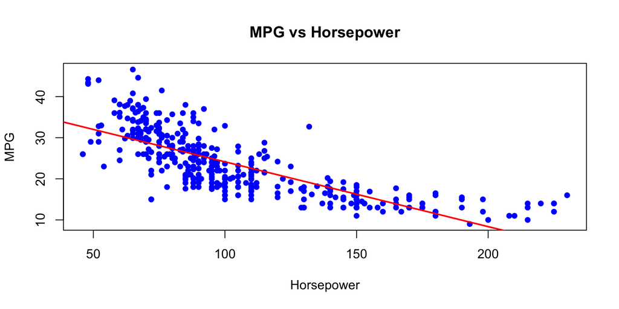

As the horsepower output of the vehicle increases, the mpg decreases.

```
##                 2.5 %    97.5 %
## (Intercept) -1519.516 -1003.580
## year            0.527     0.788
## horsepower     -0.144    -0.119
```

```
##
## Call:
## lm(formula = mpg ~ year + horsepower, data = auto)
##
## Residuals:
##     Min      1Q  Median      3Q     Max
## -12.077  -3.078  -0.431   2.588  15.315
##
## Coefficients:
##              Estimate Std. Error t value Pr(>|t|)
## (Intercept) -1.26e+03   1.31e+02   -9.61   <2e-16 ***
## year         6.57e-01   6.63e-02    9.92   <2e-16 ***
## horsepower  -1.32e-01   6.34e-03  -20.76   <2e-16 ***
## ---
## Signif. codes:  0 '***' 0.001 '**' 0.01 '*' 0.05 '.' 0.1 ' ' 1
##
## Residual standard error: 4.39 on 389 degrees of freedom
## Multiple R-squared:  0.685,  Adjusted R-squared:  0.684
## F-statistic:  424 on 2 and 389 DF,  p-value: <2e-16
```

After fitting the multiple linear regression model, while holding the horsepower constant, a one-year increase in the model year is associated with an average increase of approximately 0.657 mpg. Comparing to simple regression, where a one-year increase in model year lead to an increase of 1.23 mpg on average, after controlling for horsepower, it almost halved.

Now holding year constant, a one-unit increase in horsepower leads to a decrease of about 0.132 mpg on average. The p-values for both year and horsepower are < 2e-16, meaning they are both statistically significant at the 0.05 level.

The residual standard error suggests that the typical deviation of observed mpg values from the fitted regression surface is about 4.39 mpg.

3. The two 95% CI’s for the coefficient of year differ among (a) and (b). How would you explain the difference to a non-statistician?

For the simple regression, the 95% CI was
$$(1.06, 1.40)$$
. This means that each additional year is associated with an increase of 1.06-1.4 mpg, when year is the only predictor.

For the multiple linear regression, the 95% CI was
$$(0.527, 0.788)$$
, which means that the an increase in year leads to only abour 0.66 mpg, after adjusting for horsepower.

```
## [1] -0.416
```

Obtaining the correlation between year and horsepower, we see there is a negative correlation. This means that as year increases, horsepower tends to decrease on average. Historically, this is true, as vehicles from the 1970s had bigger engines with higher horsepower. However, after the energy crisis in the 1970s and 1980s, the sizes of engines got much smaller, which in turn decreased the horsepower output of these vehicles.

This explains why when we keep horsepower constant as year increases, the fuel economy doesn’t improve as much, giving a lower confidence interval.

4. Create a model with interaction by fitting `lm(mpg ~ year * horsepower)`. Is the interaction effect significant at .05 level? Explain the year effect (if any).

```
##
## Call:
## lm(formula = mpg ~ year * horsepower, data = auto)
##
## Residuals:
##     Min      1Q  Median      3Q     Max
## -12.349  -2.451  -0.456   2.406  14.444
##
## Coefficients:
##                  Estimate Std. Error t value Pr(>|t|)
## (Intercept)     -4.29e+03   3.19e+02   -13.5   <2e-16 ***
## year             2.19e+00   1.61e-01    13.6   <2e-16 ***
## horsepower       3.14e+01   3.08e+00    10.2   <2e-16 ***
## year:horsepower -1.60e-02   1.56e-03   -10.2   <2e-16 ***
## ---
## Signif. codes:  0 '***' 0.001 '**' 0.01 '*' 0.05 '.' 0.1 ' ' 1
##
## Residual standard error: 3.9 on 388 degrees of freedom
## Multiple R-squared:  0.752,  Adjusted R-squared:  0.75
## F-statistic:  393 on 3 and 388 DF,  p-value: <2e-16
```

The interaction between year and horsepower is statistically significant at the 0.05 level as the p-values are <2e-16. The fitted model is effectively
$$mpg =
\beta_0+\beta_1\times year+\beta_2\times horsepower+\beta_3(year\times
horsepower)$$
From this we can conclude that the effect of year now also depends on horsepower.

- For low horsepower cars → year has a larger positive effect.
- For high horsepower cars → year has a smaller positive effect.

The negative interaction coefficient of -0.016 for year:horsepower means the year improvement in mpg shrinks as horsepower increases.

## 1.3 Categorical predictors

Remember that the same variable can play different roles! Take a quick look at the variable `cylinders`, and try to use this variable in the following analyses wisely. We all agree that a larger number of cylinders will lower mpg. However, we can interpret `cylinders` as either a continuous (numeric) variable or a categorical variable.

1. Fit a model that treats `cylinders` as a continuous/numeric variable. Is `cylinders` significant at the 0.01 level? What effect does `cylinders` play in this model?

```
##
## Call:
## lm(formula = mpg ~ cylinders, data = auto)
##
## Residuals:
##     Min      1Q  Median      3Q     Max
## -14.241  -3.183  -0.633   2.549  17.917
##
## Coefficients:
##             Estimate Std. Error t value Pr(>|t|)
## (Intercept)   42.916      0.835    51.4   <2e-16 ***
## cylinders     -3.558      0.146   -24.4   <2e-16 ***
## ---
## Signif. codes:  0 '***' 0.001 '**' 0.01 '*' 0.05 '.' 0.1 ' ' 1
##
## Residual standard error: 4.91 on 390 degrees of freedom
## Multiple R-squared:  0.605,  Adjusted R-squared:  0.604
## F-statistic:  597 on 1 and 390 DF,  p-value: <2e-16
```

```
##             2.5 % 97.5 %
## (Intercept) 41.27  44.56
## cylinders   -3.84  -3.27
```

```
## [1] TRUE
```

```
## cylinders
##     -3.56
```

The p-value for `cylinders` is <2e-16, hence cylinders is statistically significant at the 0.01 level.

The slope estimate is -3.558, indicating that for each additional cylinder, the expected mpg decreases by approximately 3.558 on average.

The 95% confidence interval for the slop is
$$(-3.84, -3.27)$$
.

The entire interval is negative, confirming a strong negative relationship betwene cylinders and mpg, further highlighted in the plot below.

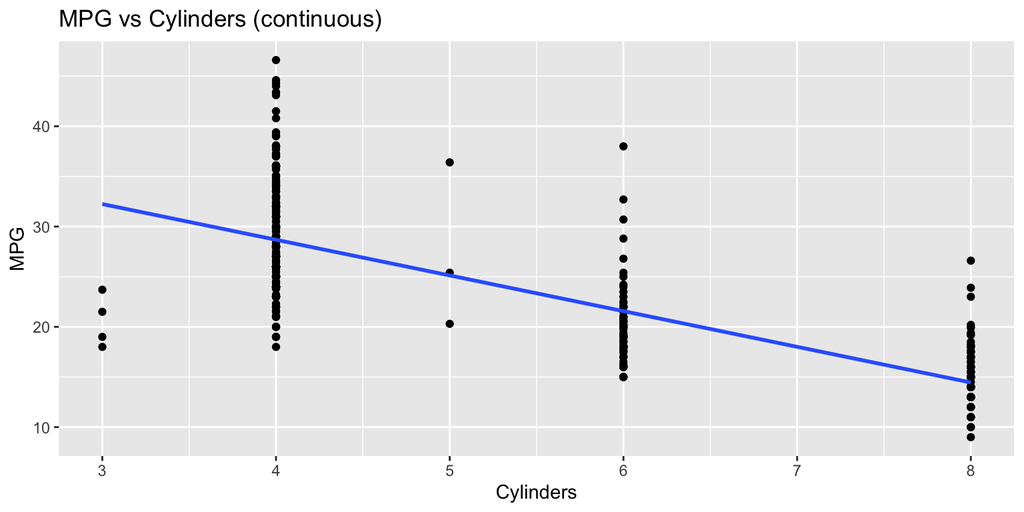

2. Fit a model that treats `cylinders` as a categorical/factor. Is `cylinders` significant at the .01 level? What is the effect of `cylinders` in this model? Describe the `cylinders` effect over `mpg`.

```
##
## Call:
## lm(formula = mpg ~ cylinders_f, data = auto)
##
## Residuals:
##     Min      1Q  Median      3Q     Max
## -11.284  -2.904  -0.963   2.344  18.027
##
## Coefficients:
##              Estimate Std. Error t value Pr(>|t|)
## (Intercept)    20.550      2.349    8.75  < 2e-16 ***
## cylinders_f4    8.734      2.373    3.68  0.00027 ***
## cylinders_f5    6.817      3.589    1.90  0.05825 .
## cylinders_f6   -0.577      2.405   -0.24  0.81071
## cylinders_f8   -5.587      2.395   -2.33  0.02015 *
## ---
## Signif. codes:  0 '***' 0.001 '**' 0.01 '*' 0.05 '.' 0.1 ' ' 1
##
## Residual standard error: 4.7 on 387 degrees of freedom
## Multiple R-squared:  0.641,  Adjusted R-squared:  0.638
## F-statistic:  173 on 4 and 387 DF,  p-value: <2e-16
```

```
##                2.5 % 97.5 %
## (Intercept)   15.931 25.169
## cylinders_f4   4.069 13.399
## cylinders_f5  -0.239 13.873
## cylinders_f6  -5.306  4.153
## cylinders_f8 -10.295 -0.879
```

```
## Anova Table (Type II tests)
##
## Response: mpg
##             Sum Sq  Df F value Pr(>F)
## cylinders_f  15275   4     173 <2e-16 ***
## Residuals     8544 387
## ---
## Signif. codes:  0 '***' 0.001 '**' 0.01 '*' 0.05 '.' 0.1 ' ' 1
```

```
## # A tibble: 5 × 4
##   cylinders_f     n mean_mpg sd_mpg
##   <fct>       <int>    <dbl>  <dbl>
## 1 3               4     20.6   2.56
## 2 4             199     29.3   5.67
## 3 5               3     27.4   8.23
## 4 6              83     20.0   3.83
## 5 8             103     15.0   2.84
```

The p-value for cylinders is still <2e-16 even as a categorical variable, significant at the 0.01 level.

Looking at the table of mean and standard deviation for the different cylinder counts, we can see that 4 cylinder vehicles have the highest mean mpg and the fuel economy decreases as the numbe rof cylinders increases. We can see that the mean mpg for 3 cylinder vehicles is fairly low, which goes against the trend identified in part a). However, we see that there are only 4 observations with 3 cylinders, so this estimate is unstable and not representative of the true fuel economy of these vehicles. This is also true for 5 cylinder vehicles, for which there were only 3 observations.

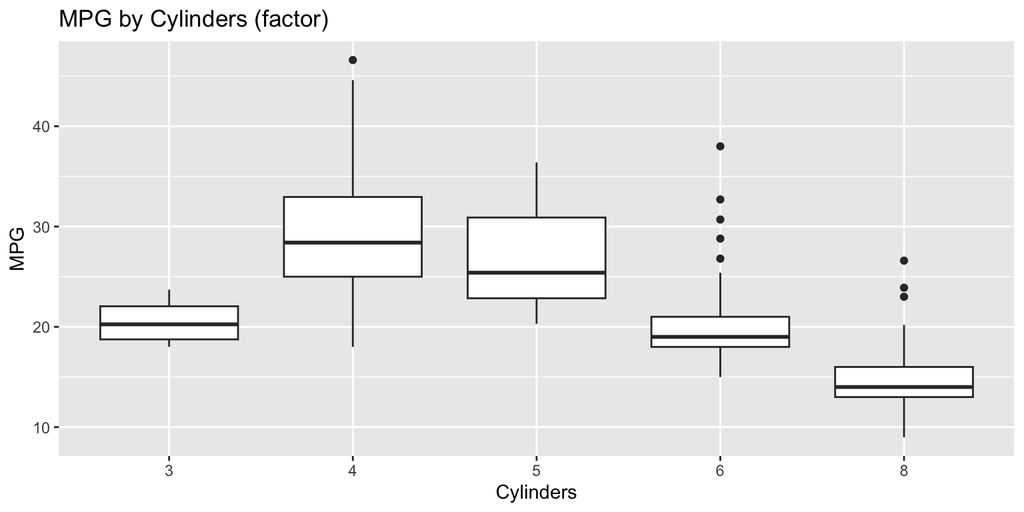

Observing the box plot we can see that there are a lot of outliers for 6 cylinder vehicles, with one vehicle achieving greater mpg than the most fuel efficient 5 cylinder vehicle. 4 cylinder vehicles have the greatest range in mpg values, but also has the most number of observations.

3. What are the fundamental differences between treating `cylinders` as a continuous and categorical variable in your models?

The numerical model assumes that
$$E[mpg|cylinders]=\beta_0+\beta_1\times cylinders$$

This forces a linear trend and imposes a constant change in mpg per each additional cylinder added.

Meanwhile, the factor model assumes that
$$E[mpg|cylinders=k]=\mu_k$$

This does not assume linearity, allowing each cylinder category to have its own mean.

4. Can you test the null hypothesis: fit0: `mpg` is linear in `cylinders` vs. fit1: `mpg` relates to `cylinders` as a categorical variable at .01 level?

```
## Analysis of Variance Table
##
## Model 1: mpg ~ cylinders
## Model 2: mpg ~ cylinders_f
##   Res.Df  RSS Df Sum of Sq    F  Pr(>F)
## 1    390 9416
## 2    387 8544  3       871 13.2 3.4e-08 ***
## ---
## Signif. codes:  0 '***' 0.001 '**' 0.01 '*' 0.05 '.' 0.1 ' ' 1
```

anova was used to compare the linear and factor models. From the ANOVA table, we see that
$$F=13.2,\qquad
p=3.4\times 10^{-8}$$

Since
$$3.4\times
10^{-8}<0.01$$
, we reject the null hypothesis at the 0.01 level, which states that the true relationship between mpg and cylinders was linear.

Hence, there is strong evidence that the relationship between mpg and cylinder is not purely linear, proving that the categorical model provides a much better fit than the linear model. Treating `cylinders` as a factor variable (which it is), is more appropriate.

## 1.4 Results

Final modeling question: we want to explore the effects of each feature as best as possible. You may explore interactions, feature transformations, higher order terms, or other strategies within reason. The model(s) should be as parsimonious (simple) as possible unless the gain in accuracy is significant from your point of view.

1. Describe the final model. Include diagnostic plots with particular focus on the model residuals and diagnoses.

```
##              displacement weight horsepower
## displacement        1.000  0.933      0.897
## weight              0.933  1.000      0.865
## horsepower          0.897  0.865      1.000
```

We can see displacement is highly correlated with both weight and horsepower, meaning keeping all three variables would not be necessary and would increase standard errors and reduce interpretability. Hence, displacement will be excluded from the final model.

The final model is
$$mpg \sim
year+weight+horsepower+cylinders+origin$$
.

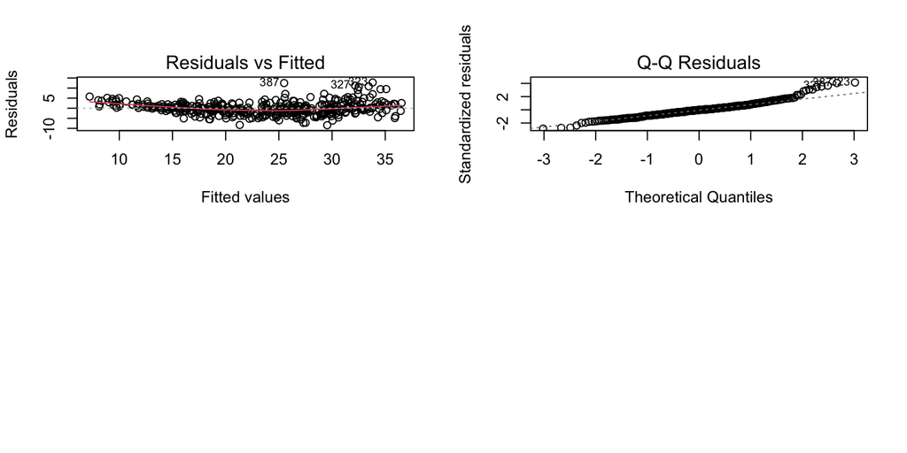

2. Summarize the effects found.

```
##
## Call:
## lm(formula = mpg ~ year + weight + horsepower + cylinders_f +
##     origin, data = auto)
##
## Residuals:
##    Min     1Q Median     3Q    Max
## -8.442 -1.953 -0.063  1.563 12.786
##
## Coefficients:
##               Estimate Std. Error t value Pr(>|t|)
## (Intercept)  -1.39e+03   9.64e+01  -14.46  < 2e-16 ***
## year          7.22e-01   4.88e-02   14.81  < 2e-16 ***
## weight       -5.10e-03   5.06e-04  -10.07  < 2e-16 ***
## horsepower   -2.54e-02   9.79e-03   -2.60  0.00977 **
## cylinders_f4  7.67e+00   1.61e+00    4.76  2.7e-06 ***
## cylinders_f5  8.39e+00   2.47e+00    3.39  0.00077 ***
## cylinders_f6  5.24e+00   1.68e+00    3.12  0.00192 **
## cylinders_f8  8.03e+00   1.79e+00    4.49  9.6e-06 ***
## originEurope  1.28e+00   5.22e-01    2.45  0.01455 *
## originJapan   2.21e+00   5.06e-01    4.38  1.6e-05 ***
## ---
## Signif. codes:  0 '***' 0.001 '**' 0.01 '*' 0.05 '.' 0.1 ' ' 1
##
## Residual standard error: 3.12 on 382 degrees of freedom
## Multiple R-squared:  0.844,  Adjusted R-squared:  0.841
## F-statistic:  230 on 9 and 382 DF,  p-value: <2e-16
```

Year and weight have p-values <2e-16. A unit increase in year leads to a 0.722 increase in mpg on average, while each pound added to a vehicle’s weight decreases its mpg by -0.0051 on average. Each additional horsepower reduces mpg by about 0.0254, but the p-value is 0.00977, which is close to the 0.01 threshold, indicating the horsepower is less statistically significant that year and weight.

Overall, fuel efficiency is strongly influenced by vehicle size, engine output, year, and country of origin.

3. Predict the `mpg` of the following car: A red car built in the US in 1983 that is 180 inches long, has eight cylinders, displaces 350 cu. inches, weighs 4000 pounds, and has a horsepower of 260. Also give a 95% CI for your prediction.

Since colour, length and displacement are not included in the model, they are not used in prediction.

```
##    fit  lwr  upr
## 1 19.5 12.9 26.1
```

Using the model described above, the predicted mpg of the vehicle is 19.5 mpg. The 95% confidence interval is
$$(12.9, 26.1)$$
.

# 2 Simple Regression through simulations

## 2.1 Linear model through simulations

This exercise is designed to help you understand the linear model using simulations. In this exercise, we will generate $(x_i, y_i)$ pairs so that all linear model assumptions are met.

Presume that $\mathbf{x}$ and $\mathbf{y}$ are linearly related with a normal error $\boldsymbol{\varepsilon}$ , such that $\mathbf{y} = 1 + 1.2\mathbf{x} + \boldsymbol{\varepsilon}$. The standard deviation of the error $\varepsilon_i$ is $\sigma = 2$.

### 2.1.1 Generate data

Create a corresponding output vector for $\mathbf{y}$ according to the equation given above. Use `set.seed(1)`. Then, create a scatterplot with $(x_i, y_i)$ pairs. Base R plotting is acceptable, but if you can, please attempt to use `ggplot2` to create the plot. Make sure to have clear labels and sensible titles on your plots.

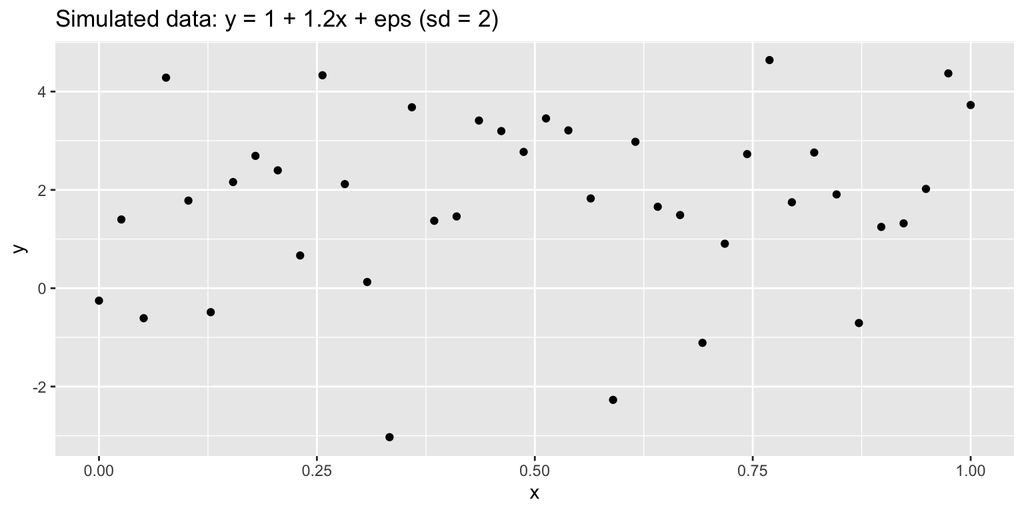

### 2.1.2 Understand the model

1. Find the LS estimates of $\boldsymbol{\beta}_0$ and $\boldsymbol{\beta}_1$, using the `lm()` function. What are the true values of $\boldsymbol{\beta}_0$ and $\boldsymbol{\beta}_1$? Do the estimates look to be good?

```
##
## Call:
## lm(formula = y ~ x, data = df)
##
## Residuals:
##    Min     1Q Median     3Q    Max
## -4.662 -0.880  0.014  1.247  2.882
##
## Coefficients:
##             Estimate Std. Error t value Pr(>|t|)
## (Intercept)    1.331      0.557    2.39    0.022 *
## x              0.906      0.959    0.95    0.350
## ---
## Signif. codes:  0 '***' 0.001 '**' 0.01 '*' 0.05 '.' 0.1 ' ' 1
##
## Residual standard error: 1.79 on 38 degrees of freedom
## Multiple R-squared:  0.023,  Adjusted R-squared:  -0.00272
## F-statistic: 0.894 on 1 and 38 DF,  p-value: 0.35
```

```
## (Intercept)
##        1.33
```

```
##     x
## 0.906
```

The true values for $\beta_0 and \beta_1$ are 1 and 1.2 respectively.

2. What is your RSE for this linear model fit? Is it close to $\sigma = 2$?

```
## [1] 1.79
```

The residual standard error of 1.79 is fairly close to the true value $\sigma = 2$.

3. What is the 95% confidence interval for $\boldsymbol{\beta}_1$? Does this confidence interval capture the true $\boldsymbol{\beta}_1$?

```
##  2.5 % 97.5 %
##  -1.03   2.85
```

We have a 95% confidence interval of $(-1.03, 2.85)$, which includes the true value $\boldsymbol{\beta}_1=1.2$.

4. Overlay the LS estimates and the true lines of the mean function onto a copy of the scatterplot you made above.

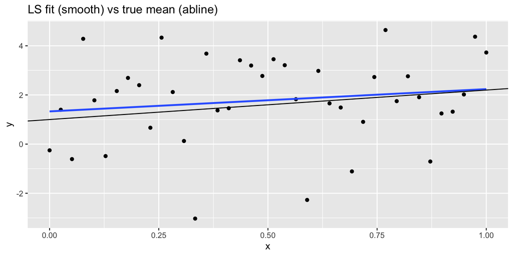

The black line is the true mean function. The blue line is the least squares fitted line. The two lines are fairly close, with minor deviations at lower x values.

### 2.1.3 diagnoses

1. Provide residual plot where fitted $\mathbf{y}$-values are on the x-axis and residuals are on the y-axis.

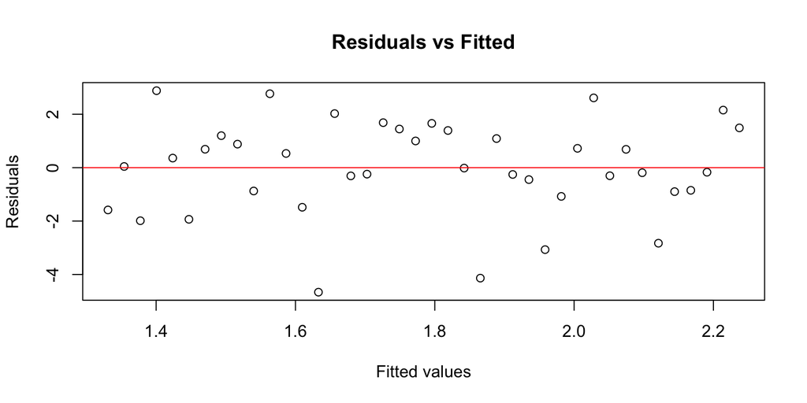

2. Provide a normal QQ plot of the residuals.

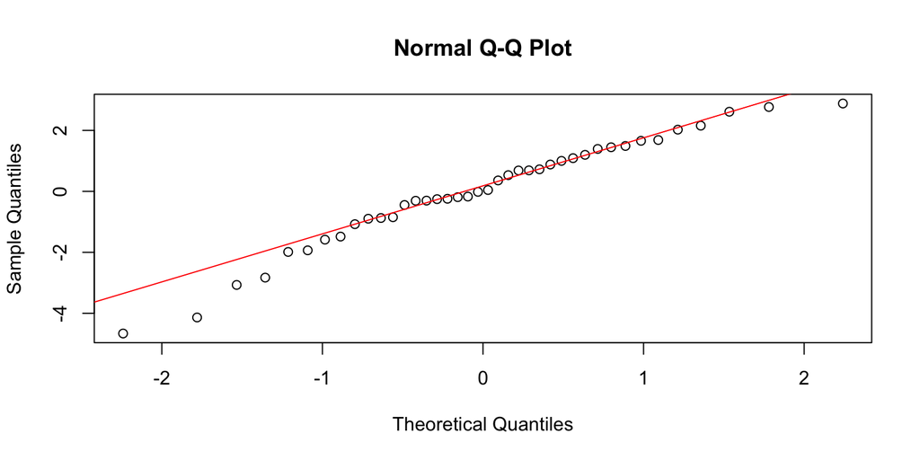

3. Comment on how well the model assumptions are met for the sample you used.

The residuals vs fitted plot shows no systematic pattern or curvature. The residuals are randomly scattered around zero, with approximately constant spread, suggesting that the linearity and homoscedasticity assumptions are satisfied.

From the Q-Q plot we can see that several points fall below the reference line in the lower tail. However, this is expected for a small sample size of 40. The remaining points lie closely to the reference line.

Linear model assumptions are well satisfied in this sample.

## 2.2 Understand sampling distribution and confidence intervals

This part aims to help you understand the notion of sampling statistics and confidence intervals. Let’s concentrate on estimating the slope only.

Generate 100 samples of size $n = 40$, and estimate the slope coefficient from each sample. Also construct 95% confidence intervals for the slope.

1. Summarize the LS estimates of the slope. Does the sampling distribution agree with theory? (First specify the theoretical sampling distribution of the LS estimate.)

```
## [1] 1.04
```

```
## [1] 1.1
```

```
## [1] 1.07
```

Under a simple linear model
$$y_i=\beta_0+\beta_1x_i+\epsilon_i,\qquad
\epsilon_i\sim N(0,\sigma^2)$$
with fixed $x_1,...,x_n$, the least squares slope satisfies
$$\hat\beta_1\sim
N\bigg(\beta_1,\frac{\sigma^2}{S_{xx}}\bigg),\quad where \ \
S_{xx}=\sum_{i=1}^n(x_i-\bar x)^2.$$
In this simulation, we have $\beta_1=1.2 \ and \ \sigma=2$, so

$$\hat{\beta}_1 \sim N\!\left(1.2,\;
\frac{4}{S_{xx}}\right), \quad \text{and} \quad
\mathrm{SD}(\hat{\beta}_1) = \frac{2}{\sqrt{S_{xx}}}.$$
The simulated standard deviation of 1.1 is close to the theoretical value of 1.07, so the variability matches the theory well. However, the simulated mean for the slope of 1.04 is slightly below the true slope of 1.2. Theoretically we would have $E[\hat\beta_1]=\beta_1$. This discrepancy can be improved by conducting more simulations, and the simulated mean will converge to the true value.

2. How many of your 95% confidence intervals capture the true $\boldsymbol{\beta}_1$? Display your confidence intervals graphically.

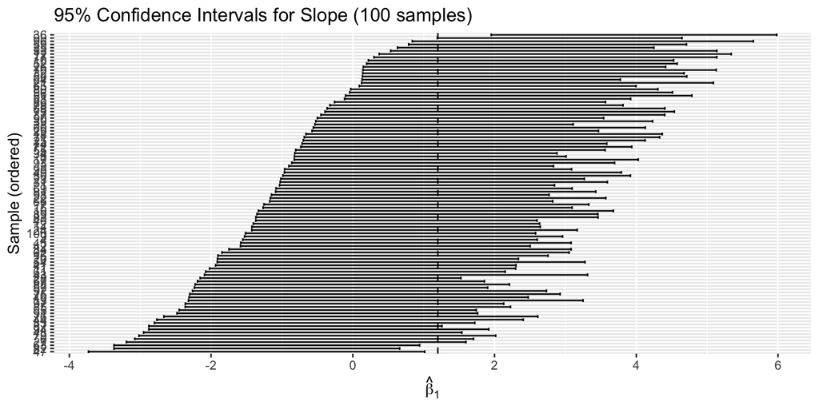

```
## [1] 0.96
```

Out of 100 simulated samples, 96 of the 95% confidence intervals contained the true slope $\beta_1=1.2$. This empirical coverage rate of 96% is very close to the theoretical coverage of 95%.